# R Notebook

```r
library(forecast)
```

```r
library(graphics)
library(TTR)
library(TSA)
library(dplyr)
library(forecast)
library(lmtest)
library(orcutt)
library(HoRM)
library(corrplot)
library(dLagM)
library(dynlm)
library(MLmetrics)
library(ggplot2)
library(tsibble)
library(tseries)
library(MASS)
library(aTSA)
```

# Import Data

```r
library(rio)
dt <- import("https://raw.githubusercontent.com/Prratama/MPDW/main/Data/mpdw1.csv")
```

# Data Time Series

```r
ts5 <- ts(dt$Harga)
ts5
```

```
## Time Series:
## Start = 1
## End = 122
## Frequency = 1
##   [1] 36400 36300 36300 36700 38500 38700 38200 37900 38700 38000 38500 37000
##  [13] 37700 37200 37000 37000 37000 36800 37000 37200 36800 36800 36800 38300
##  [25] 36800 37300 37300 37300 37300 37300 37100 37500 37000 36600 36200 36500
##  [37] 36500 36300 36100 37200 36800 37000 36700 36500 36500 36500 36700 35000
##  [49] 36500 36500 36200 37000 36500 37500 38300 36500 37000 36800 37300 38000
##  [61] 37300 36700 36800 36800 36500 36800 37300 36300 36300 36400 35500 36400
##  [73] 36700 36000 36500 36600 35900 37100 37100 36900 36100 36800 35600 35300
##  [85] 35300 35000 34900 34400 35800 36100 36400 36700 36500 37400 37000 36600
##  [97] 36800 37700 37200 37700 37200 37700 37000 37700 37500 37200 37000 36800
## [109] 36700 36900 36700 37000 37000 37000 36700 37000 36800 36800 37000 37000
## [121] 37000 37000
```

```r
summary(ts5)
```

```
##    Min. 1st Qu.  Median    Mean 3rd Qu.    Max.
##   34400   36500   36800   36843   37200   38700
```

# Membagi data menjadi data latih (80%) dan data uji (20%) dan jadikan time series

```r
latih <- dt[1:98,2]
tes <- dt[99:122,2]
traints <- ts(latih, frequency = 12)
testts <- ts(tes, frequency = 12)
```

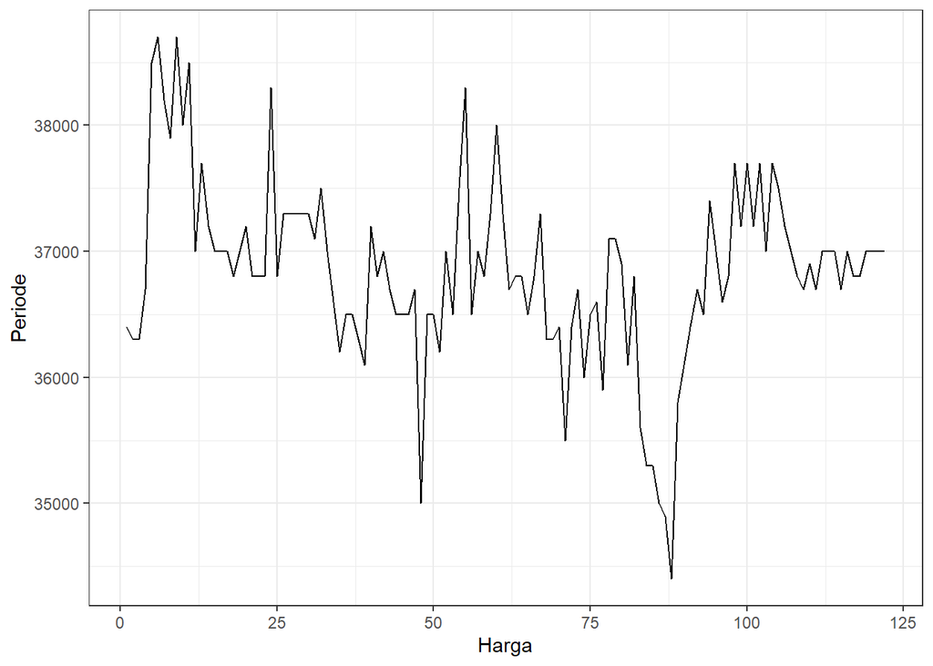

```r
library(ggplot2)
library(tsibble)
plot_stas <- ts5 |> as_tsibble() |>
  ggplot(aes(x = index, y = value)) + geom_line() + theme_bw() +
  xlab("Harga") + ylab("Periode")
plot_stas
```

```r
mean(ts5)
```

```
## [1] 36842.62
```

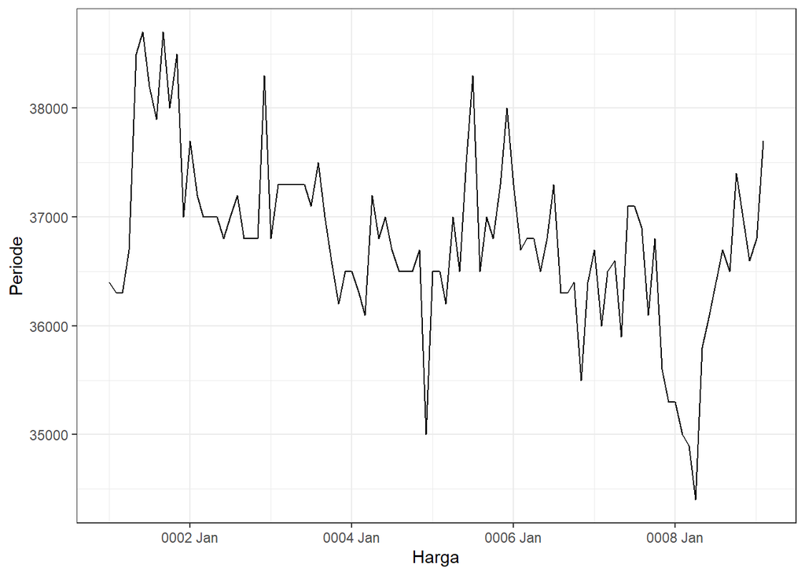

```r
plot_trstas <- traints |> as_tsibble() |>
  ggplot(aes(x = index, y = value)) + geom_line() + theme_bw() +
  xlab("Harga") + ylab("Periode")
plot_trstas
```

```r
mean(ts5)
```

```
## [1] 36842.62
```

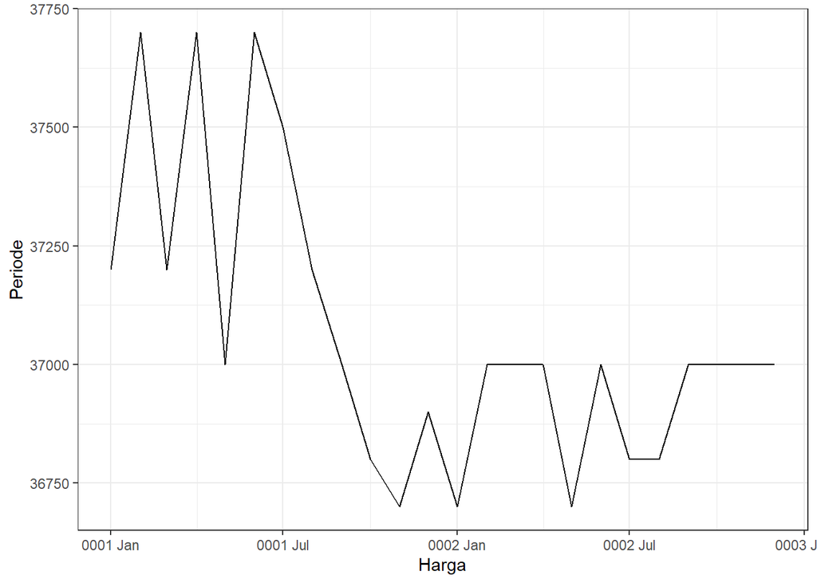

```r
plot_testas <- testts |> as_tsibble() |>
  ggplot(aes(x = index, y = value)) + geom_line() + theme_bw() +
  xlab("Harga") + ylab("Periode")
plot_testas
```

```r
mean(ts5)
```

```
## [1] 36842.62
```

# Check Stasioner

#Plot acf

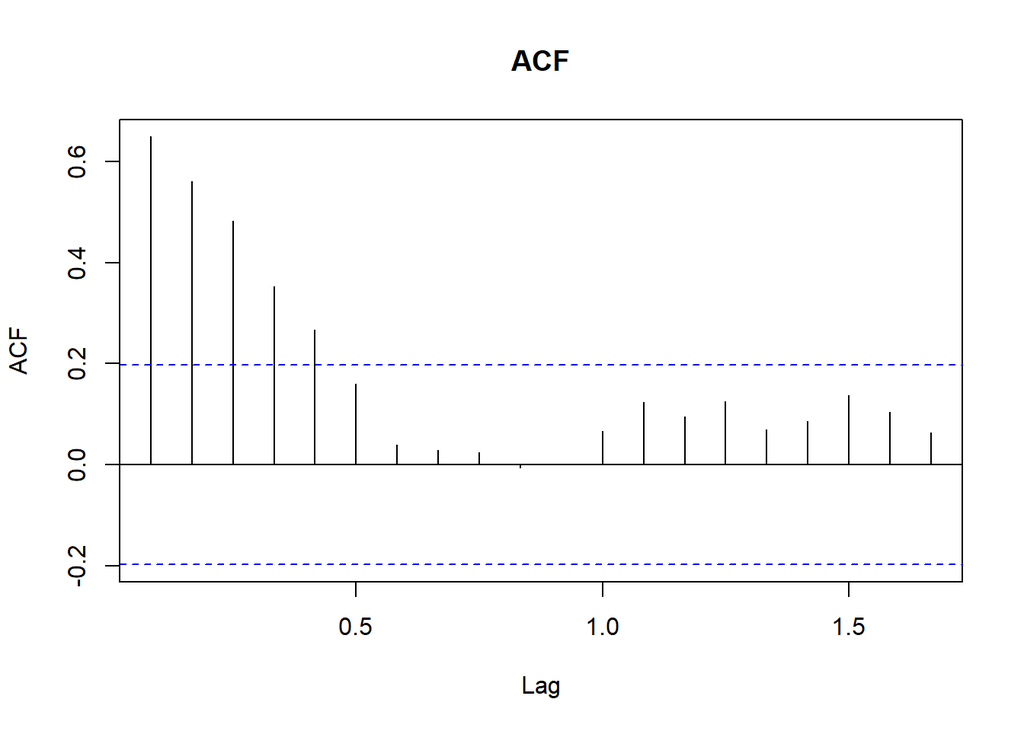

```r
acf(traints, main="ACF", lag.max=20)
```

#Uji ADF

```r
tseries::adf.test(traints)
```

```
##
##  Augmented Dickey-Fuller Test
##
## data:  traints
## Dickey-Fuller = -3.2368, Lag order = 4, p-value = 0.08589
## alternative hypothesis: stationary
```

$H_0$ : Data tidak stasioner dalam rataan

$H_1$ : Data stasioner dalam rataan

Berdasarkan uji ADF tersebut, didapat *p-value* sebesar 0.086 yang lebih besar dari taraf nyata 5% sehingga tak tolak $H_0$ dan menandakan bahwa data tidak stasioner dalam rataan. Hal ini sesuai dengan hasil eksplorasi menggunakan plot time series dan plot ACF.

# Penanganan Data Tidak Stasioner dalam Rataan

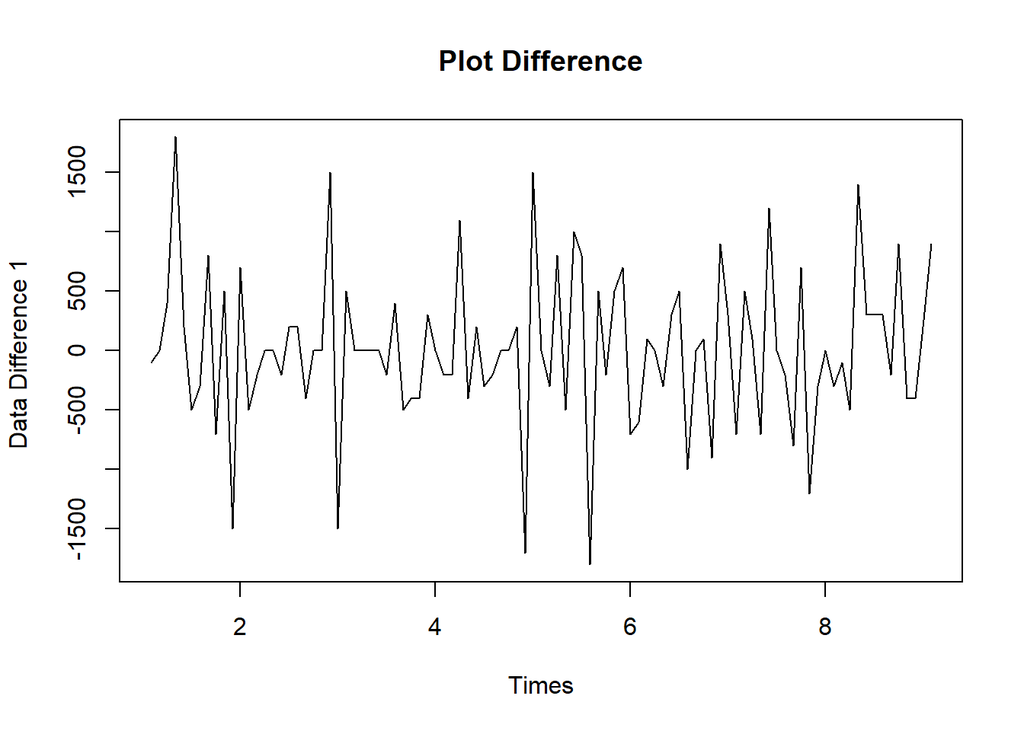

```r
traindiff<-diff(traints,differences = 1)
plot.ts(traindiff, lty=1, xlab="Times", ylab="Data Difference 1 ", main="Plot Difference")
```

terlihat pada plot tersebut data sudah stasioner dalam rataan ditandai dengan data bergerak pada nilai tengah.

#Plot ACF dan PACF Setelah Penanganan

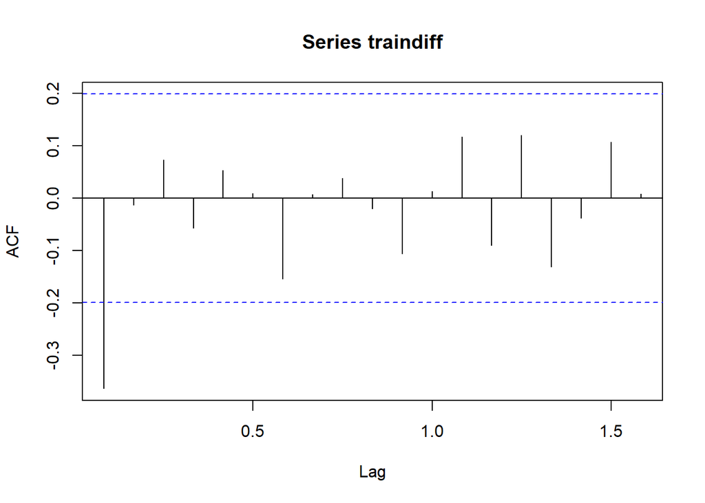

```r
acf_trainnew <-acf(traindiff)
```

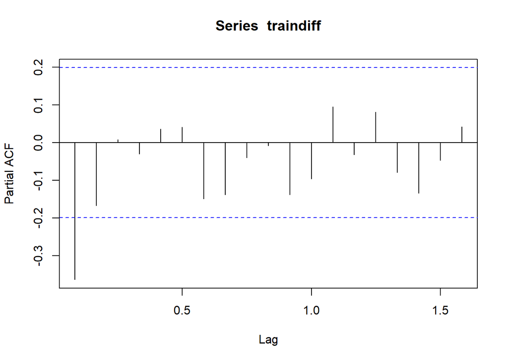

```r
pacf_trainnew <- pacf(traindiff)
```

#Uji ADF

```r
tseries::adf.test(traindiff)
```

```
##
##  Augmented Dickey-Fuller Test
##
## data:  traindiff
## Dickey-Fuller = -5.2872, Lag order = 4, p-value = 0.01
## alternative hypothesis: stationary
```

$H_0$ : Data tidak stasioner dalam rataan

$H_1$ : Data stasioner dalam rataan

Berdasarkan uji ADF tersebut, didapat *p-value* sebesar 0.01 yang lebih kecil dari taraf nyata 5% sehingga tolak $H_0$ atau data stasioner dalam rataan. Sehingga dalam hal ini ketidakstasioneran data sudah berhasil ditangani dan dapat dilanjutkan ke pemodelan

#Plot EACF

```r
eacf(traindiff)
```

```
## AR/MA
##   0 1 2 3 4 5 6 7 8 9 10 11 12 13
## 0 x o o o o o o o o o o  o  o  o
## 1 x o o o o o o o o o o  o  o  o
## 2 o o o o o o o o o o o  o  o  o
## 3 x o o o o o o o o o o  o  o  o
## 4 x o o o o o o o o o o  o  o  o
## 5 x o o o o o o o o o o  o  o  o
## 6 x o o o o x o o o o o  o  o  o
## 7 x x o x x o o o o o o  o  o  o
```

Identifikasi model menggunakan plot EACF dilakukan dengan melihat ujung segitiga pada pola segitiga nol. Dalam hal ini model tentatif yang terbentuk adalah ARIMA(0,1,1), ARIMA(1,1,1), ARIMA(2,1,0), dan ARIMA(3,1,1).

#ARIMA(1,1,0)

```r
model1.da = Arima(traindiff,order=c(1,1,0),method = "ML")
summary(model1.da)
```

```
## Series: traindiff
## ARIMA(1,1,0)
##
## Coefficients:
##           ar1
##       -0.6237
## s.e.   0.0787
##
## sigma^2 = 719663:  log likelihood = -783.32
## AIC=1570.63   AICc=1570.76   BIC=1575.76
##
## Training set error measures:
##                    ME     RMSE      MAE MPE MAPE      MASE       ACF1
## Training set 12.01212 839.5381 648.0213 NaN  Inf 0.9529725 -0.3108193
```

```r
coeftest(model1.da)
```

```
##
## z test of coefficients:
##
##      Estimate Std. Error z value  Pr(>|z|)
## ar1 -0.623695   0.078677 -7.9273 2.239e-15 ***
## ---
## Signif. codes:  0 '***' 0.001 '**' 0.01 '*' 0.05 '.' 0.1 ' ' 1
```

#ARIMA(0,1,1)

```r
model2.da = Arima(traindiff,order=c(0,1,1),method = "ML")
summary(model2.da)
```

```
## Series: traindiff
## ARIMA(0,1,1)
##
## Coefficients:
##           ma1
##       -1.0000
## s.e.   0.0276
##
## sigma^2 = 439507:  log likelihood = -761.69
## AIC=1527.37   AICc=1527.5   BIC=1532.5
##
## Training set error measures:
##                     ME     RMSE      MAE MPE MAPE      MASE       ACF1
## Training set -18.47244 656.0834 482.7941 NaN  Inf 0.7099913 -0.3608318
```

```r
coeftest(model2.da)
```

```
##
## z test of coefficients:
##
##      Estimate Std. Error z value  Pr(>|z|)
## ma1 -0.999985   0.027591 -36.244 < 2.2e-16 ***
## ---
## Signif. codes:  0 '***' 0.001 '**' 0.01 '*' 0.05 '.' 0.1 ' ' 1
```

#ARIMA(1,1,1)

```r
model3.da = Arima(traindiff,order=c(1,1,1),method = "ML")
summary(model3.da)
```

```
## Series: traindiff
## ARIMA(1,1,1)
##
## Coefficients:
##           ar1      ma1
##       -0.3601  -1.0000
## s.e.   0.0955   0.0299
##
## sigma^2 = 384382:  log likelihood = -755.12
## AIC=1516.24   AICc=1516.5   BIC=1523.93
##
## Training set error measures:
##                     ME     RMSE      MAE MPE MAPE      MASE        ACF1
## Training set -32.26461 610.3229 457.7621 NaN  Inf 0.6731796 -0.06823221
```

```r
coeftest(model3.da)
```

```
##
## z test of coefficients:
##
##      Estimate Std. Error z value  Pr(>|z|)
## ar1 -0.360133   0.095500  -3.771 0.0001626 ***
## ma1 -0.999999   0.029928 -33.414 < 2.2e-16 ***
## ---
## Signif. codes:  0 '***' 0.001 '**' 0.01 '*' 0.05 '.' 0.1 ' ' 1
```

#ARIMA(2,1,0)

```r
model4.da = Arima(traindiff,order=c(2,1,0),method = "ML")
summary(model4.da)
```

```
## Series: traindiff
## ARIMA(2,1,0)
##
## Coefficients:
##           ar1      ar2
##       -0.9373  -0.4895
## s.e.   0.0890   0.0883
##
## sigma^2 = 549846:  log likelihood = -770.17
## AIC=1546.34   AICc=1546.6   BIC=1554.03
##
## Training set error measures:
##                    ME     RMSE      MAE MPE MAPE      MASE       ACF1
## Training set 10.43233 729.9595 544.4288 NaN  Inf 0.8006306 -0.1569141
```

```r
coeftest(model4.da)
```

```
##
## z test of coefficients:
##
##      Estimate Std. Error z value  Pr(>|z|)
## ar1 -0.937280   0.088952 -10.537 < 2.2e-16 ***
## ar2 -0.489524   0.088345  -5.541 3.007e-08 ***
## ---
## Signif. codes:  0 '***' 0.001 '**' 0.01 '*' 0.05 '.' 0.1 ' ' 1
```

#ARIMA(3,1,1)

```r
model5.da = Arima(traindiff,order=c(3,1,1),method = "ML")
summary(model5.da)
```

```
## Series: traindiff
## ARIMA(3,1,1)
##
## Coefficients:
##           ar1      ar2     ar3      ma1
##       -0.4203  -0.1565  0.0187  -1.0000
## s.e.   0.1035   0.1112  0.1027   0.0316
##
## sigma^2 = 380781:  log likelihood = -753.8
## AIC=1517.6   AICc=1518.27   BIC=1530.42
##
## Training set error measures:
##                     ME     RMSE      MAE MPE MAPE      MASE        ACF1
## Training set -41.64694 600.9602 450.6961 NaN  Inf 0.6627885 -0.01028864
```

```r
coeftest(model5.da)
```

```
##
## z test of coefficients:
##
##      Estimate Std. Error  z value  Pr(>|z|)
## ar1 -0.420332   0.103455  -4.0629 4.846e-05 ***
## ar2 -0.156526   0.111204  -1.4076    0.1593
## ar3  0.018683   0.102672   0.1820    0.8556
## ma1 -1.000000   0.031569 -31.6768 < 2.2e-16 ***
## ---
## Signif. codes:  0 '***' 0.001 '**' 0.01 '*' 0.05 '.' 0.1 ' ' 1
```

# analisis sisaan

### Eksplorasi model terbaik

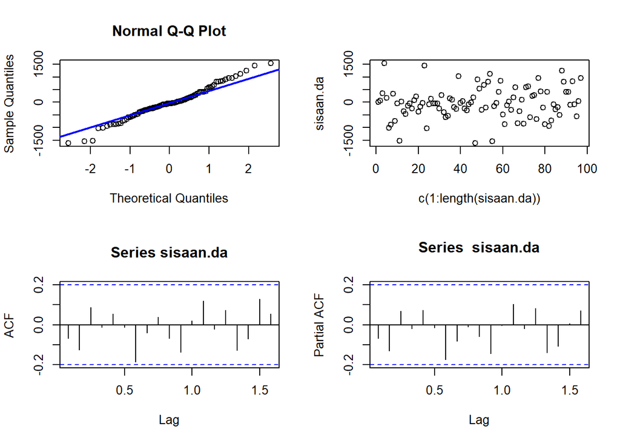

```r
#Eksplorasi
sisaan.da <- model3.da$residuals
par(mfrow=c(2,2))
qqnorm(sisaan.da)
qqline(sisaan.da, col = "blue", lwd = 2)
plot(c(1:length(sisaan.da)),sisaan.da)
acf(sisaan.da)
pacf(sisaan.da)
```

```r
par(mfrow = c(1,1))
```

### Uji Formal

```r
#1) Sisaan Menyebar Normal
ks.test(sisaan.da,"pnorm")
```

```
##
##  Exact one-sample Kolmogorov-Smirnov test
##
## data:  sisaan.da
## D = 0.56696, p-value = 5.551e-16
## alternative hypothesis: two-sided
```

$H_0$ : Sisaan menyebar normal

$H_1$ : Sisaan tidak menyebar normal

```r
#2) Sisaan saling bebas/tidak ada autokorelasi
Box.test(sisaan.da, type = "Ljung")
```

```
##
##  Box-Ljung test
##
## data:  sisaan.da
## X-squared = 0.46571, df = 1, p-value = 0.495
```

$H_0$ : Sisaan saling bebas

$H_1$ : Sisaan tidak tidak saling bebas

Berdasarkan uji Ljung-Box tersebut, didapat *p-value* sebesar 0.495 yang lebih besar dari taraf nyata 5% sehingga tak tolak $H_0$ dan menandakan bahwa sisaan saling bebas. Artinya tidak ada autokorelasi

```r
#3) Sisaan homogen
Box.test((sisaan.da)^2, type = "Ljung")
```

```
##
##  Box-Ljung test
##
## data:  (sisaan.da)^2
## X-squared = 0.22924, df = 1, p-value = 0.6321
```

$H_0$ : Ragam sisaan homogen

$H_1$ : Ragam sisaan tidak homogen

Berdasarkan uji Ljung-Box tersebut. didapat *p-value* sebesar 0.6321 yang lebih besar dari taraf nyata 5% sehingga tak tolak $H_0$ dan menandakan bahwa ragam sisaan homogen

```r
#4) Nilai tengah sisaan sama dengan nol
t.test(sisaan.da, mu = 0, conf.level = 0.95)  #tak tolak h0 > nilai tengah sisaan sama dengan 0
```

```
##
##  One Sample t-test
##
## data:  sisaan.da
## t = -0.51869, df = 96, p-value = 0.6052
## alternative hypothesis: true mean is not equal to 0
## 95 percent confidence interval:
##  -155.73801   91.20879
## sample estimates:
## mean of x
## -32.26461
```

$H_0$ : nilai tengah sisaan sama dengan 0

$H_1$ : nilai tengah sisaan tidak sama dengan 0

Berdasarkan uji-ttersebut, didapat *p-value* sebesar 0.6052 yang lebih besar dari taraf nyata 5% sehingga tak tolak $H_0$ dan menandakan bahwa nilai tengah sisaan sama dengan 0

# Overfitting

### ARIMA(1,1,2)

```r
modelov=Arima(traints, order=c(1,1,2),method="ML")
summary(modelov)
```

```
## Series: traints
## ARIMA(1,1,2)
##
## Coefficients:
##          ar1      ma1     ma2
##       0.2287  -0.6653  0.1442
## s.e.  0.8865   0.8879  0.4166
##
## sigma^2 = 374324:  log likelihood = -758.6
## AIC=1525.21   AICc=1525.64   BIC=1535.51
##
## Training set error measures:
##                    ME     RMSE      MAE       MPE     MAPE      MASE
## Training set 16.09249 599.2037 443.6199 0.0254242 1.204963 0.5914932
##                       ACF1
## Training set -0.0008710308
```

```r
lmtest::coeftest(modelov)
```

```
##
## z test of coefficients:
##
##     Estimate Std. Error z value Pr(>|z|)
## ar1  0.22871    0.88647  0.2580   0.7964
## ma1 -0.66534    0.88794 -0.7493   0.4537
## ma2  0.14419    0.41660  0.3461   0.7293
```

berdasarkan hasil overfitting yg terbaik tetap model ARIMA(1,1,1).

# Peramalan

```r
#---FORECAST---#
ramal <- forecast::forecast(model3.da, h = 24)
ramal
```

```
##        Point Forecast      Lo 80    Hi 80     Lo 95    Hi 95
## Mar  9    -308.777827 -1107.4285 489.8729 -1530.209  912.653
## Apr  9     126.543366  -719.5389 972.6257 -1167.428 1420.515
## May  9     -30.230308  -883.2664 822.8058 -1334.836 1274.376
## Jun  9      26.229119  -827.3467 879.8049 -1279.202 1331.661
## Jul  9       5.896197  -847.8785 859.6709 -1299.840 1311.632
## Aug  9      13.218760  -840.5353 866.9729 -1292.485 1318.923
## Sep  9      10.581661  -843.1865 864.3498 -1295.144 1316.307
## Oct  9      11.531368  -842.2326 865.2953 -1294.188 1317.251
## Nov  9      11.189347  -842.5762 864.9549 -1294.532 1316.911
## Dec  9      11.312520  -842.4525 865.0775 -1294.408 1317.033
## Jan 10      11.268161  -842.4971 865.0334 -1294.453 1316.989
## Feb 10      11.284136  -842.4810 865.0493 -1294.437 1317.005
## Mar 10      11.278383  -842.4868 865.0435 -1294.443 1317.000
## Apr 10      11.280455  -842.4847 865.0456 -1294.441 1317.002
## May 10      11.279709  -842.4854 865.0449 -1294.441 1317.001
## Jun 10      11.279978  -842.4852 865.0451 -1294.441 1317.001
## Jul 10      11.279881  -842.4853 865.0450 -1294.441 1317.001
## Aug 10      11.279916  -842.4852 865.0451 -1294.441 1317.001
## Sep 10      11.279903  -842.4853 865.0451 -1294.441 1317.001
## Oct 10      11.279908  -842.4852 865.0451 -1294.441 1317.001
## Nov 10      11.279906  -842.4853 865.0451 -1294.441 1317.001
## Dec 10      11.279907  -842.4853 865.0451 -1294.441 1317.001
## Jan 11      11.279906  -842.4853 865.0451 -1294.441 1317.001
## Feb 11      11.279907  -842.4853 865.0451 -1294.441 1317.001
```

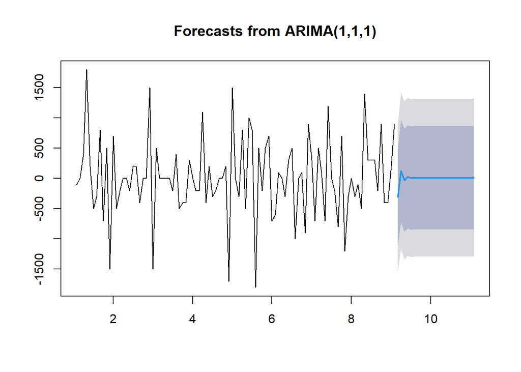

```r
dataramal <- ramal$mean
plot(ramal)
```

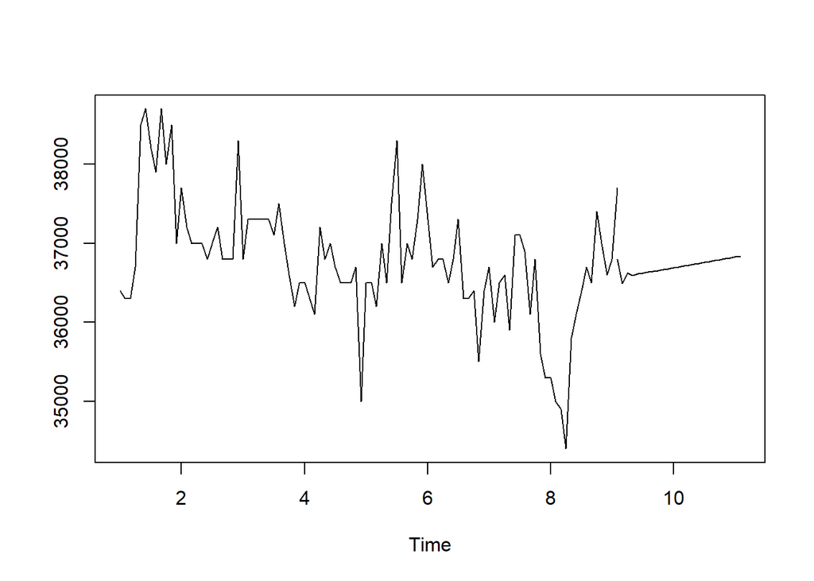

```r
pt.1 <- traints[97] #nilai akhir data latih
hasilforc.Diff <- dataramal
hasil <- diffinv(hasilforc.Diff, differences = 1) + pt.1
#has.1 sama hasilnta dengan: cumsum(c(pt_1,hasil.forc.Diff))
ts.plot(traints,hasil)
```

# AKURASI

```r
perbandingan <- matrix(data=c(head(testts, n=24), hasil[-1]),
                     nrow = 24, ncol = 2)
colnames(perbandingan) <- c("Aktual","Hasil Forecast")
perbandingan
```

```
##       Aktual Hasil Forecast
##  [1,]  37200       36491.22
##  [2,]  37700       36617.77
##  [3,]  37200       36587.54
##  [4,]  37700       36613.76
##  [5,]  37000       36619.66
##  [6,]  37700       36632.88
##  [7,]  37500       36643.46
##  [8,]  37200       36654.99
##  [9,]  37000       36666.18
## [10,]  36800       36677.49
## [11,]  36700       36688.76
## [12,]  36900       36700.05
## [13,]  36700       36711.32
## [14,]  37000       36722.61
## [15,]  37000       36733.89
## [16,]  37000       36745.17
## [17,]  36700       36756.44
## [18,]  37000       36767.72
## [19,]  36800       36779.00
## [20,]  36800       36790.28
## [21,]  37000       36801.56
## [22,]  37000       36812.84
## [23,]  37000       36824.12
## [24,]  37000       36835.40
```

```r
accuracy(hasil[-1], head(testts, n=24))
```

```
##                ME     RMSE      MAE       MPE      MAPE      ACF1 Theil's U
## Test set 363.5774 504.6534 369.2249 0.9735629 0.9889512 0.5949822    1.5352
```